# Projet Régression 2017

Bénédicte <>, Xian YANG xian.yang@etu.univ-lyon1.fr

24 déc. 2017

## 0. Introduction

In this article we will present four common feature selection techniques in regression problems with the help of some chemical reaction data. The data devide into two parts: the first dataset consists of 100 chemical substances with each having 50 numeric measurements, called descriptors. The second one consists of 25 chemical substances with the same measurements, apart from the fact that to each of them an additional numeric mark is given, that we will call response. The response occupies the second column of the second dataset, which looks like below

```r
head(dfAvecObs, n = 1L)
```

```
## # A tibble: 1 x 52
##      rowname reponse descripteur2 descripteur3 descripteur4 descripteur6
##        <chr>   <dbl>        <dbl>        <dbl>        <dbl>        <dbl>
## 1 mol_nouv_1 344.569     158.5826    -707.1099    -2.480062  -0.00925984
## # ... with 46 more variables: descripteur7 <dbl>, descripteur8 <dbl>,
## #   descripteur12 <dbl>, descripteur14 <dbl>, descripteur15 <dbl>,
## #   descripteur16 <dbl>, descripteur17 <dbl>, descripteur18 <dbl>,
## #   descripteur20 <dbl>, descripteur21 <dbl>, descripteur23 <dbl>,
## #   descripteur26 <dbl>, descripteur27 <dbl>, descripteur28 <dbl>,
## #   descripteur29 <dbl>, descripteur30 <dbl>, descripteur31 <dbl>,
## #   descripteur32 <dbl>, descripteur34 <dbl>, descripteur35 <dbl>,
## #   descripteur36 <dbl>, descripteur37 <dbl>, descripteur39 <dbl>,
## #   descripteur40 <dbl>, descripteur43 <dbl>, descripteur44 <dbl>,
## #   descripteur45 <dbl>, descripteur47 <dbl>, descripteur49 <dbl>,
## #   descripteur50 <dbl>, descripteur51 <dbl>, descripteur53 <dbl>,
## #   descripteur54 <dbl>, descripteur55 <dbl>, descripteur58 <dbl>,
## #   descripteur60 <dbl>, descripteur61 <dbl>, descripteur62 <dbl>,
## #   descripteur64 <dbl>, descripteur65 <dbl>, descripteur67 <dbl>,
## #   descripteur68 <dbl>, descripteur69 <dbl>, descripteur70 <dbl>,
## #   descripteur72 <dbl>, descripteur73 <dbl>
```

```r
dim(dfSansObs) # dont une colonne est le nom d'observation
```

```
## [1] 100  51
```

```r
dim(dfAvecObs) # dont une colonne est le nom d'observation
```

```
## [1] 25 52
```

```r
summary(dfAvecObs$reponse)
```

```
##    Min. 1st Qu.  Median    Mean 3rd Qu.    Max.
##   340.6   341.8   346.3   346.7   349.5   360.2
```

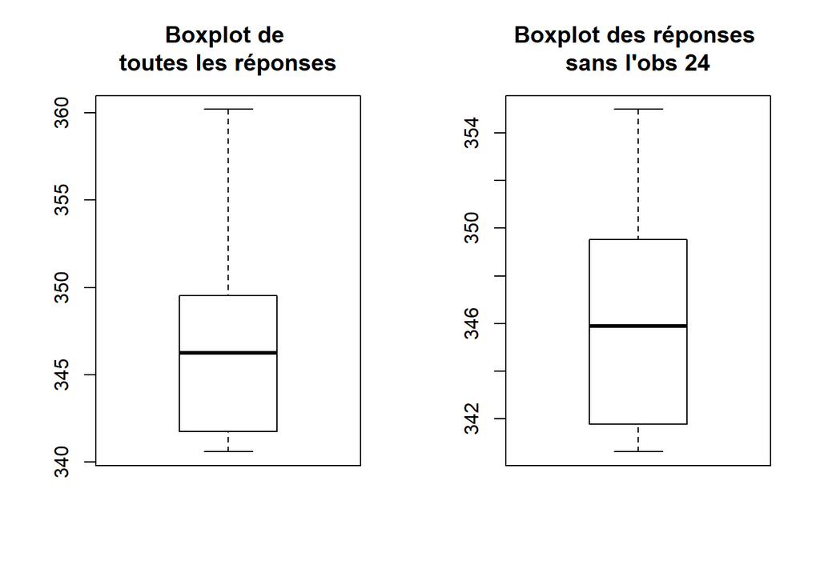

```r
oldpar = par(mfrow = c(1, 2))
boxplot(dfAvecObs$reponse, main = "Boxplot de \ntoutes les réponses")
boxplot(dfAvecObs$reponse[-24], main = "Boxplot des réponses \nsans l'obs 24")
```

```r
par(oldpar)
table(dfAvecObs$descripteur14)
```

```
##
## 1 2 3 4 5
## 4 8 9 2 2
```

```r
table(dfSansObs$descripteur14)
```

```
##
##  0  1  2  3  4  5  6  7  8 10
##  1 12 20 26 20  6  9  3  2  1
```

## I. Unsupervised stepwise feature selection among main effects using VIF

```
## 30 variables from the 50 input variables have collinearity problem:
##
## descripteur54 descripteur37 descripteur12 descripteur64 descripteur73 descripteur53 descripteur20 descripteur2 descripteur4 descripteur27 descripteur34 descripteur44 descripteur32 descripteur21 descripteur55 descripteur58 descripteur43 descripteur35 descripteur17 descripteur62 descripteur40 descr…
##
## After excluding the collinear variables, the linear correlation coefficients ranges between:
## min correlation ( descripteur36 ~ descripteur8 ):  0.002851837
## max correlation ( descripteur7 ~ descripteur6 ):  0.8923239
##
## ---------- VIFs of the remained variables --------
##        Variables      VIF
## 1   descripteur3 4.191740
## 2   descripteur6 9.088015
## 3   descripteur7 7.818435
## 4   descripteur8 1.752169
## 5  descripteur14 6.512348
## 6  descripteur15 2.715454
## 7  descripteur23 2.593388
## 8  descripteur30 6.175346
## 9  descripteur31 4.903179
## 10 descripteur36 2.766559
## 11 descripteur39 5.307234
## 12 descripteur45 1.726331
## 13 descripteur47 1.781837
## 14 descripteur49 3.439896
## 15 descripteur51 3.562749
## 16 descripteur60 2.876118
## 17 descripteur61 4.313321
## 18 descripteur68 3.085346
## 19 descripteur69 4.491104
## 20 descripteur70 2.326613
```

## II. Supervised stepwise feature selection with interaction terms of degree 2 (3 main effects at most)

Cette fonction prend 3 indices en entrée, effectue avec ces 3 variables et 3 interactions une sélection bidirectionnelle par AIC et retourne la PRESS du meilleur modèle (du plus petit AIC).

```r
meilleurModele3Var <- function(i, j, k) {
  modeleComplet <- lm(reponse ~ .^2,
                      data = dfAvecObs[c("reponse", as.character(VifEffetsPrincipaux@results$Variables)[c(i, j, k)])])
  meilleurModele <- stepAIC(modeleComplet, direction = "both", trace = FALSE)
  press <- MPV::PRESS(meilleurModele)
  return(press)
}
```

Cette fonction, même qu’avant, retourne en revanche le modèle au lieu de sa PRESS.

```r
meilleurModele3VarResume <- function(i, j, k) {
  modeleComplet <- lm(reponse ~ .^2,
                      data = dfAvecObs[c("reponse", as.character(VifEffetsPrincipaux@results$Variables)[c(i, j, k)])])
  meilleurModele <- stepAIC(modeleComplet, direction = "both", trace = FALSE)
}
```

```r
RSS <- array(1000, dim = rep(length(variablesReduites), times = 3))
```

Parcourir tous les 3-uplets possibles et stocker la PRESS du meilleur modèle de chaque 3-uplet

```r
lapply(1:(length(variablesReduites) - 2), function(i) {
  lapply((i+1):(length(variablesReduites) - 1), function(j) {
    lapply ((j+1):length(variablesReduites), function(k) RSS[i, j, k] <<- meilleurModele3Var(i, j, k) )
  })
})
minimum <- min(RSS)
```

Minimum global de la PRESS

```r
minimum
```

```
## [1] 196.8261
```

Quel modèle c’est ?

```r
which(minimum == RSS, arr.ind = TRUE)
```

```
##      dim1 dim2 dim3
## [1,]    8   17   18
```

Extraire ce modèle

```r
meill2 <- meilleurModele3VarResume(8, 17, 18)
```

Revoyons son AIC

```r
AIC(meill2)
```

```
## [1] 126.4526
```

Maintenant, on effectue une analyse sur le modèle de régression sélectionné.  
Regardons d’abord les graphes ensemble :

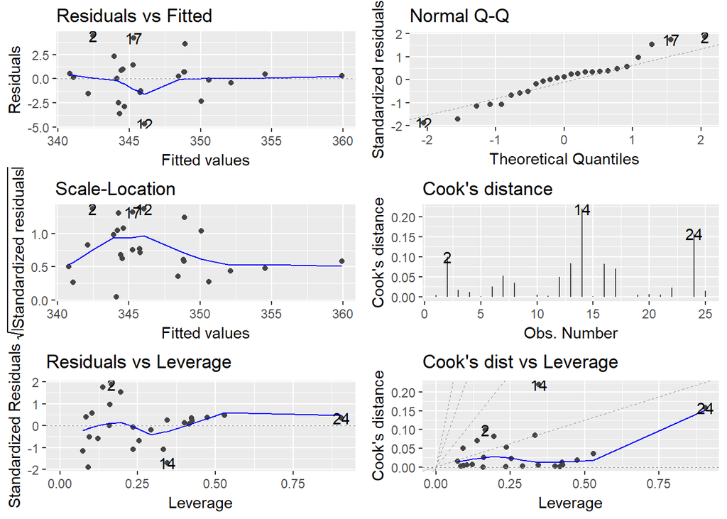

```r
autoplot(meill2, which = 1:6) # Outliers : 12 (le pire), 2, 17). High leverage : 24
```

On fait un test pour être sûr des valeurs abberantes :

```r
car::outlierTest(meill2) # Effectivement, 12 a le plus grand résidu studentisé.
```

```
##
## No Studentized residuals with Bonferonni p < 0.05
## Largest |rstudent|:
##     rstudent unadjusted p-value Bonferonni p
## 12 -2.043417           0.056828           NA
```

En outres, est-ce que ce modèle passe toutes les hypothèses de la régression linéaire ?

```r
summary(gvlma(meill2)) # Oui. En outre, R carré pas mal.
```

```
##
## Call:
## lm(formula = reponse ~ (descripteur30 + descripteur61 + descripteur68)^2,
##     data = dfAvecObs[c("reponse", as.character(VifEffetsPrincipaux@results$Variables)[c(i,
##         j, k)])])
##
## Residuals:
##     Min      1Q  Median      3Q     Max
## -4.6664 -1.4435  0.2626  0.8320  4.4399
##
## Coefficients:
##                             Estimate Std. Error t value Pr(>|t|)
## (Intercept)                  362.845      7.784  46.614  < 2e-16 ***
## descripteur30                 -2.208      4.259  -0.518 0.610533
## descripteur61                181.703     34.338   5.292 4.96e-05 ***
## descripteur68                 11.346     27.522   0.412 0.685019
## descripteur30:descripteur61  -42.900     14.576  -2.943 0.008693 **
## descripteur30:descripteur68  -25.671     14.000  -1.834 0.083298 .
## descripteur61:descripteur68 -301.462     71.352  -4.225 0.000509 ***
## ---
## Signif. codes:  0 '***' 0.001 '**' 0.01 '*' 0.05 '.' 0.1 ' ' 1
##
## Residual standard error: 2.597 on 18 degrees of freedom
## Multiple R-squared:  0.7915, Adjusted R-squared:  0.722
## F-statistic: 11.39 on 6 and 18 DF,  p-value: 2.706e-05
##
##
## ASSESSMENT OF THE LINEAR MODEL ASSUMPTIONS
## USING THE GLOBAL TEST ON 4 DEGREES-OF-FREEDOM:
## Level of Significance =  0.05
##
## Call:
##  gvlma(x = meill2)
##
##                      Value p-value                Decision
## Global Stat        0.51083  0.9724 Assumptions acceptable.
## Skewness           0.01656  0.8976 Assumptions acceptable.
## Kurtosis           0.01883  0.8909 Assumptions acceptable.
## Link Function      0.39646  0.5289 Assumptions acceptable.
## Heteroscedasticity 0.07898  0.7787 Assumptions acceptable.
```

```r
# Enlever le 12 d'abord ?
nouveau1 <- lm(meill2$terms, data = dfAvecObs[-12, ])
summary(nouveau1)
```

```
##
## Call:
## lm(formula = meill2$terms, data = dfAvecObs[-12, ])
##
## Residuals:
##     Min      1Q  Median      3Q     Max
## -3.5003 -1.5951  0.1846  0.8791  3.9881
##
## Coefficients:
##                             Estimate Std. Error t value Pr(>|t|)
## (Intercept)                  363.439      7.183  50.600  < 2e-16 ***
## descripteur30                 -2.637      3.933  -0.670  0.51158
## descripteur61                170.752     32.109   5.318 5.67e-05 ***
## descripteur68                  8.585     25.411   0.338  0.73963
## descripteur30:descripteur61  -39.726     13.528  -2.937  0.00922 **
## descripteur30:descripteur68  -23.472     12.952  -1.812  0.08766 .
## descripteur61:descripteur68 -285.755     66.232  -4.314  0.00047 ***
## ---
## Signif. codes:  0 '***' 0.001 '**' 0.01 '*' 0.05 '.' 0.1 ' ' 1
##
## Residual standard error: 2.394 on 17 degrees of freedom
## Multiple R-squared:  0.8238, Adjusted R-squared:  0.7616
## F-statistic: 13.24 on 6 and 17 DF,  p-value: 1.383e-05
```

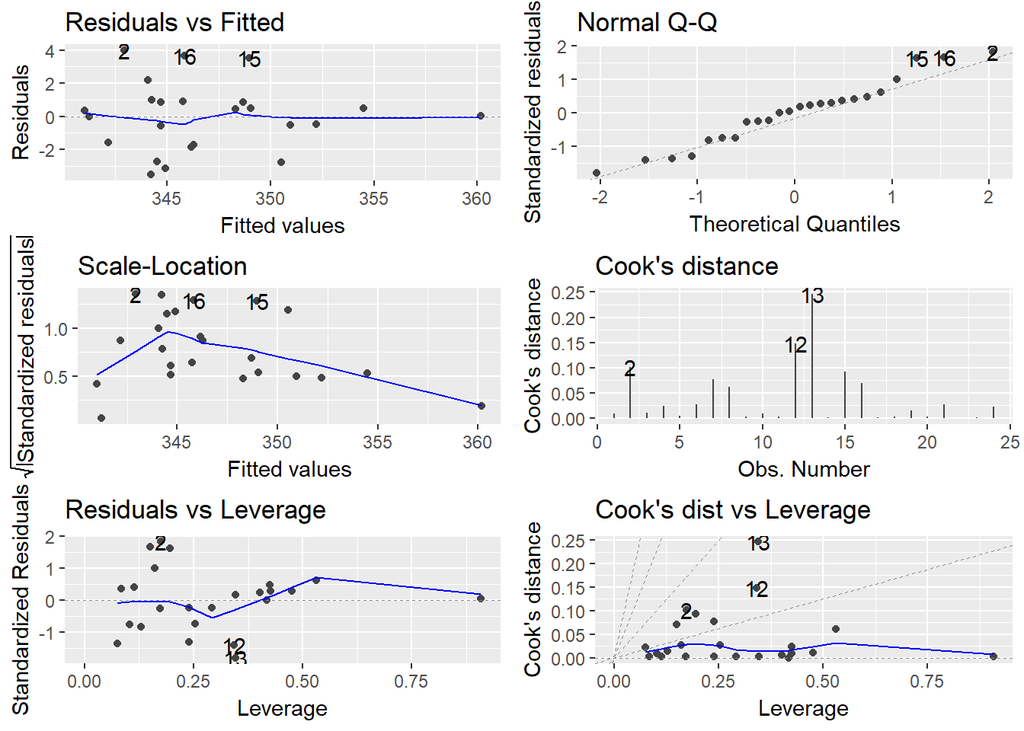

```r
autoplot(nouveau1, which = 1:6)
```

```r
car::outlierTest(nouveau1)
```

```
##
## No Studentized residuals with Bonferonni p < 0.05
## Largest |rstudent|:
##   rstudent unadjusted p-value Bonferonni p
## 2  1.98515           0.064545           NA
```

```r
summary(gvlma(nouveau1))
```

```
##
## Call:
## lm(formula = meill2$terms, data = dfAvecObs[-12, ])
##
## Residuals:
##     Min      1Q  Median      3Q     Max
## -3.5003 -1.5951  0.1846  0.8791  3.9881
##
## Coefficients:
##                             Estimate Std. Error t value Pr(>|t|)
## (Intercept)                  363.439      7.183  50.600  < 2e-16 ***
## descripteur30                 -2.637      3.933  -0.670  0.51158
## descripteur61                170.752     32.109   5.318 5.67e-05 ***
## descripteur68                  8.585     25.411   0.338  0.73963
## descripteur30:descripteur61  -39.726     13.528  -2.937  0.00922 **
## descripteur30:descripteur68  -23.472     12.952  -1.812  0.08766 .
## descripteur61:descripteur68 -285.755     66.232  -4.314  0.00047 ***
## ---
## Signif. codes:  0 '***' 0.001 '**' 0.01 '*' 0.05 '.' 0.1 ' ' 1
##
## Residual standard error: 2.394 on 17 degrees of freedom
## Multiple R-squared:  0.8238, Adjusted R-squared:  0.7616
## F-statistic: 13.24 on 6 and 17 DF,  p-value: 1.383e-05
##
##
## ASSESSMENT OF THE LINEAR MODEL ASSUMPTIONS
## USING THE GLOBAL TEST ON 4 DEGREES-OF-FREEDOM:
## Level of Significance =  0.05
##
## Call:
##  gvlma(x = nouveau1)
##
##                       Value p-value                Decision
## Global Stat        0.438541  0.9792 Assumptions acceptable.
## Skewness           0.154147  0.6946 Assumptions acceptable.
## Kurtosis           0.224617  0.6355 Assumptions acceptable.
## Link Function      0.008111  0.9282 Assumptions acceptable.
## Heteroscedasticity 0.051666  0.8202 Assumptions acceptable.
```

```r
nouveau2 <- lm(meill2$terms, data = dfAvecObs[-c(2, 12), ])

summary(nouveau2)
```

```
##
## Call:
## lm(formula = meill2$terms, data = dfAvecObs[-c(2, 12), ])
##
## Residuals:
##     Min      1Q  Median      3Q     Max
## -3.1068 -1.3221  0.0086  0.7510  4.2787
##
## Coefficients:
##                             Estimate Std. Error t value Pr(>|t|)
## (Intercept)                  364.290      6.646  54.816  < 2e-16 ***
## descripteur30                 -2.777      3.632  -0.765 0.455598
## descripteur61                188.528     30.970   6.087 1.57e-05 ***
## descripteur68                  9.144     23.464   0.390 0.701887
## descripteur30:descripteur61  -43.433     12.630  -3.439 0.003371 **
## descripteur30:descripteur68  -24.189     11.965  -2.022 0.060262 .
## descripteur61:descripteur68 -310.565     62.418  -4.976 0.000137 ***
## ---
## Signif. codes:  0 '***' 0.001 '**' 0.01 '*' 0.05 '.' 0.1 ' ' 1
##
## Residual standard error: 2.211 on 16 degrees of freedom
## Multiple R-squared:  0.8586, Adjusted R-squared:  0.8056
## F-statistic: 16.19 on 6 and 16 DF,  p-value: 5.5e-06
```

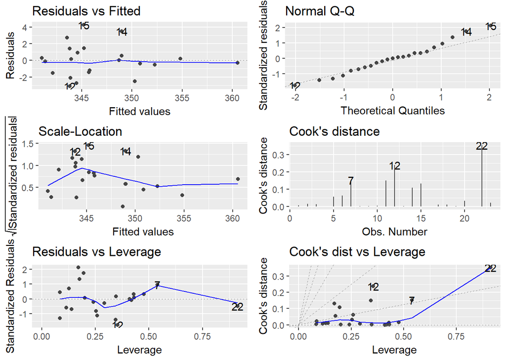

```r
autoplot(nouveau2, which = 1:6)
```

```r
car::outlierTest(nouveau2)
```

```
##
## No Studentized residuals with Bonferonni p < 0.05
## Largest |rstudent|:
##    rstudent unadjusted p-value Bonferonni p
## 15 2.427517           0.028261         0.65
```

```r
summary(gvlma(nouveau2)) # Assez bien au niveau graphique.
```

```
##
## Call:
## lm(formula = meill2$terms, data = dfAvecObs[-c(2, 12), ])
##
## Residuals:
##     Min      1Q  Median      3Q     Max
## -3.1068 -1.3221  0.0086  0.7510  4.2787
##
## Coefficients:
##                             Estimate Std. Error t value Pr(>|t|)
## (Intercept)                  364.290      6.646  54.816  < 2e-16 ***
## descripteur30                 -2.777      3.632  -0.765 0.455598
## descripteur61                188.528     30.970   6.087 1.57e-05 ***
## descripteur68                  9.144     23.464   0.390 0.701887
## descripteur30:descripteur61  -43.433     12.630  -3.439 0.003371 **
## descripteur30:descripteur68  -24.189     11.965  -2.022 0.060262 .
## descripteur61:descripteur68 -310.565     62.418  -4.976 0.000137 ***
## ---
## Signif. codes:  0 '***' 0.001 '**' 0.01 '*' 0.05 '.' 0.1 ' ' 1
##
## Residual standard error: 2.211 on 16 degrees of freedom
## Multiple R-squared:  0.8586, Adjusted R-squared:  0.8056
## F-statistic: 16.19 on 6 and 16 DF,  p-value: 5.5e-06
##
##
## ASSESSMENT OF THE LINEAR MODEL ASSUMPTIONS
## USING THE GLOBAL TEST ON 4 DEGREES-OF-FREEDOM:
## Level of Significance =  0.05
##
## Call:
##  gvlma(x = nouveau2)
##
##                       Value p-value                Decision
## Global Stat        1.610946  0.8068 Assumptions acceptable.
## Skewness           0.733485  0.3918 Assumptions acceptable.
## Kurtosis           0.009833  0.9210 Assumptions acceptable.
## Link Function      0.541123  0.4620 Assumptions acceptable.
## Heteroscedasticity 0.326506  0.5677 Assumptions acceptable.
```

```r
# nouveau21 <- lm(meill$terms, data = dfAvecObs[-c(3, 12, 16), ])
# summary(nouveau21)
# autoplot(nouveau21)
# car::outlierTest(nouveau21)
# summary(gvlma(nouveau21))
```

```r
nouveau3 <- lm(meill2$terms, data = dfAvecObs[-c(12, 2, 17), ])
summary(nouveau3)
```

```
##
## Call:
## lm(formula = meill2$terms, data = dfAvecObs[-c(12, 2, 17), ])
##
## Residuals:
##     Min      1Q  Median      3Q     Max
## -3.1962 -0.8425 -0.0003  0.8638  3.4615
##
## Coefficients:
##                             Estimate Std. Error t value Pr(>|t|)
## (Intercept)                  362.519      5.861  61.850  < 2e-16 ***
## descripteur30                 -1.647      3.212  -0.513 0.615535
## descripteur61                206.277     28.071   7.348 2.41e-06 ***
## descripteur68                 18.234     20.872   0.874 0.396104
## descripteur30:descripteur61  -47.634     11.187  -4.258 0.000688 ***
## descripteur30:descripteur68  -29.383     10.687  -2.749 0.014902 *
## descripteur61:descripteur68 -336.563     55.662  -6.047 2.24e-05 ***
## ---
## Signif. codes:  0 '***' 0.001 '**' 0.01 '*' 0.05 '.' 0.1 ' ' 1
##
## Residual standard error: 1.935 on 15 degrees of freedom
## Multiple R-squared:  0.8972, Adjusted R-squared:  0.8561
## F-statistic: 21.82 on 6 and 15 DF,  p-value: 1.3e-06
```

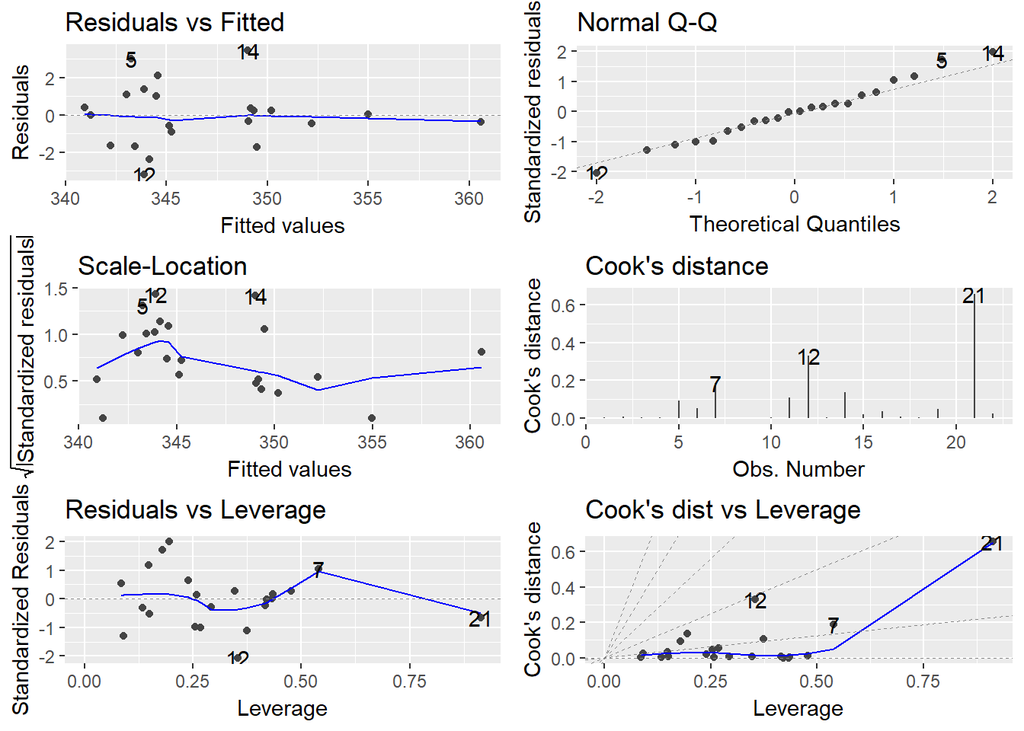

```r
autoplot(nouveau3, which = 1:6)
```

```r
car::outlierTest(nouveau3)
```

```
##
## No Studentized residuals with Bonferonni p < 0.05
## Largest |rstudent|:
##     rstudent unadjusted p-value Bonferonni p
## 12 -2.343107           0.034412      0.75707
```

```r
summary(gvlma(nouveau3))
```

```
##
## Call:
## lm(formula = meill2$terms, data = dfAvecObs[-c(12, 2, 17), ])
##
## Residuals:
##     Min      1Q  Median      3Q     Max
## -3.1962 -0.8425 -0.0003  0.8638  3.4615
##
## Coefficients:
##                             Estimate Std. Error t value Pr(>|t|)
## (Intercept)                  362.519      5.861  61.850  < 2e-16 ***
## descripteur30                 -1.647      3.212  -0.513 0.615535
## descripteur61                206.277     28.071   7.348 2.41e-06 ***
## descripteur68                 18.234     20.872   0.874 0.396104
## descripteur30:descripteur61  -47.634     11.187  -4.258 0.000688 ***
## descripteur30:descripteur68  -29.383     10.687  -2.749 0.014902 *
## descripteur61:descripteur68 -336.563     55.662  -6.047 2.24e-05 ***
## ---
## Signif. codes:  0 '***' 0.001 '**' 0.01 '*' 0.05 '.' 0.1 ' ' 1
##
## Residual standard error: 1.935 on 15 degrees of freedom
## Multiple R-squared:  0.8972, Adjusted R-squared:  0.8561
## F-statistic: 21.82 on 6 and 15 DF,  p-value: 1.3e-06
##
##
## ASSESSMENT OF THE LINEAR MODEL ASSUMPTIONS
## USING THE GLOBAL TEST ON 4 DEGREES-OF-FREEDOM:
## Level of Significance =  0.05
##
## Call:
##  gvlma(x = nouveau3)
##
##                      Value p-value                Decision
## Global Stat        0.85723  0.9306 Assumptions acceptable.
## Skewness           0.21216  0.6451 Assumptions acceptable.
## Kurtosis           0.01076  0.9174 Assumptions acceptable.
## Link Function      0.34869  0.5549 Assumptions acceptable.
## Heteroscedasticity 0.28561  0.5930 Assumptions acceptable.
```

```r
nouveau4 <- lm(meill2$terms, data = dfAvecObs[-c(3, 24), ])
summary(nouveau4)
```

```
##
## Call:
## lm(formula = meill2$terms, data = dfAvecObs[-c(3, 24), ])
##
## Residuals:
##     Min      1Q  Median      3Q     Max
## -4.1388 -1.3489 -0.1418  1.3006  4.0555
##
## Coefficients:
##                             Estimate Std. Error t value Pr(>|t|)
## (Intercept)                  363.296      9.809  37.038  < 2e-16 ***
## descripteur30                 -2.102      5.465  -0.385  0.70559
## descripteur61                138.377     73.006   1.895  0.07625 .
## descripteur68                -31.032     59.921  -0.518  0.61162
## descripteur30:descripteur61  -24.672     32.882  -0.750  0.46396
## descripteur30:descripteur68  -11.060     23.226  -0.476  0.64037
## descripteur61:descripteur68 -323.757     86.693  -3.735  0.00181 **
## ---
## Signif. codes:  0 '***' 0.001 '**' 0.01 '*' 0.05 '.' 0.1 ' ' 1
##
## Residual standard error: 2.7 on 16 degrees of freedom
## Multiple R-squared:  0.6933, Adjusted R-squared:  0.5783
## F-statistic: 6.027 on 6 and 16 DF,  p-value: 0.001868
```

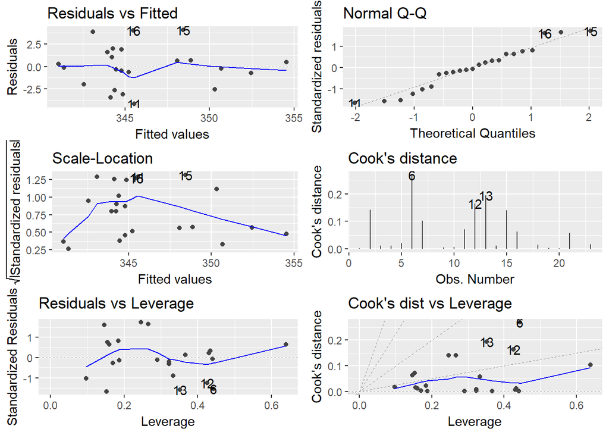

```r
autoplot(nouveau4, which = 1:6)
```

```r
car::outlierTest(nouveau4)
```

```
##
## No Studentized residuals with Bonferonni p < 0.05
## Largest |rstudent|:
##    rstudent unadjusted p-value Bonferonni p
## 15 1.858226           0.082873           NA
```

```r
summary(gvlma(nouveau4))
```

```
##
## Call:
## lm(formula = meill2$terms, data = dfAvecObs[-c(3, 24), ])
##
## Residuals:
##     Min      1Q  Median      3Q     Max
## -4.1388 -1.3489 -0.1418  1.3006  4.0555
##
## Coefficients:
##                             Estimate Std. Error t value Pr(>|t|)
## (Intercept)                  363.296      9.809  37.038  < 2e-16 ***
## descripteur30                 -2.102      5.465  -0.385  0.70559
## descripteur61                138.377     73.006   1.895  0.07625 .
## descripteur68                -31.032     59.921  -0.518  0.61162
## descripteur30:descripteur61  -24.672     32.882  -0.750  0.46396
## descripteur30:descripteur68  -11.060     23.226  -0.476  0.64037
## descripteur61:descripteur68 -323.757     86.693  -3.735  0.00181 **
## ---
## Signif. codes:  0 '***' 0.001 '**' 0.01 '*' 0.05 '.' 0.1 ' ' 1
##
## Residual standard error: 2.7 on 16 degrees of freedom
## Multiple R-squared:  0.6933, Adjusted R-squared:  0.5783
## F-statistic: 6.027 on 6 and 16 DF,  p-value: 0.001868
##
##
## ASSESSMENT OF THE LINEAR MODEL ASSUMPTIONS
## USING THE GLOBAL TEST ON 4 DEGREES-OF-FREEDOM:
## Level of Significance =  0.05
##
## Call:
##  gvlma(x = nouveau4)
##
##                        Value p-value                Decision
## Global Stat        4.032e-01  0.9822 Assumptions acceptable.
## Skewness           2.811e-02  0.8669 Assumptions acceptable.
## Kurtosis           3.621e-01  0.5473 Assumptions acceptable.
## Link Function      1.300e-02  0.9092 Assumptions acceptable.
## Heteroscedasticity 4.790e-06  0.9983 Assumptions acceptable.
```

```r
# Enlever 24puis 3 peut être une autre option.
```

## III. Méthode alternative : stepwise directement avec toutes les variables

On établit d’abord le modèle de départ et le modèle d’arrivé, entre lesquels on cherchera le modèle optimal. On accepte toutes les variables qui restent après l’opération de recherche de linéarités préliminaire, ainsi que leurs interactions de second degré.

```r
modeleDepart <- lm(reponse ~ 1,
                   data = dfAvecObs[c("reponse", as.character(VifEffetsPrincipaux@results$Variables))])
modeleComplet <- lm(reponse ~ .^2,
                    data = dfAvecObs[c("reponse", as.character(VifEffetsPrincipaux@results$Variables))])
```

Maintenant on va efffctuer la sélection des variables stepwise, avec respctivement les critères AIC et BIC. Sachant que dans un contexte que le nombre de variables est égal au nombre d’observation, la sélection backward n’est pas possible, on peut alors choisir entre “forward” et “bidirectional”. Du coup nous avons 4 combinaisons possible devant nous.

Forward + AIC

AIC ends at `-Inf`, which means perfect fit. Not good. We don’t take into account this result.

Forward + BIC

On arrive à un bon résultat avec trois variables de degré 1 et une interaction de degré 2.

Bidirectional AIC

On arrive à un bon résultat avec quatre variables de degré 1 et deux interactions de degré 2.

Bidirectional BIC

Celui-ci done le même résultat que forward BIC.

En fin du compte, on garde les deux modèles obtenus respectivement par forward BIC et bidirectional AIC. On peut ensuite étudier leurs qualités de régression en ragardant certains critères.  
On peut d’abord regarder leurs R carrés.

```r
summary(forwardBIC)
```

```
##
## Call:
## lm(formula = reponse ~ descripteur30 + descripteur8 + descripteur39 +
##     descripteur8:descripteur39, data = dfAvecObs[c("reponse",
##     as.character(VifEffetsPrincipaux@results$Variables))])
##
## Residuals:
##     Min      1Q  Median      3Q     Max
## -5.2252 -2.3937 -0.5834  2.5760  4.1208
##
## Coefficients:
##                              Estimate Std. Error t value Pr(>|t|)
## (Intercept)                348.540867   2.683107 129.902  < 2e-16 ***
## descripteur30               -4.950314   1.023709  -4.836  0.00010 ***
## descripteur8                 4.315046   1.164961   3.704  0.00140 **
## descripteur39                0.006967   0.001893   3.681  0.00148 **
## descripteur8:descripteur39  -0.004747   0.001816  -2.614  0.01663 *
## ---
## Signif. codes:  0 '***' 0.001 '**' 0.01 '*' 0.05 '.' 0.1 ' ' 1
##
## Residual standard error: 3.004 on 20 degrees of freedom
## Multiple R-squared:   0.69,  Adjusted R-squared:  0.628
## F-statistic: 11.13 on 4 and 20 DF,  p-value: 6.468e-05
```

```r
summary(bidirectionalAIC)
```

```
##
## Call:
## lm(formula = reponse ~ descripteur30 + descripteur8 + descripteur39 +
##     descripteur31 + descripteur30:descripteur39 + descripteur30:descripteur31,
##     data = dfAvecObs[c("reponse", as.character(VifEffetsPrincipaux@results$Variables))])
##
## Residuals:
##     Min      1Q  Median      3Q     Max
## -4.2751 -0.8758 -0.2047  1.0612  3.8226
##
## Coefficients:
##                               Estimate Std. Error t value Pr(>|t|)
## (Intercept)                 358.327910   2.334952 153.463  < 2e-16 ***
## descripteur30               -21.740375   2.791524  -7.788 3.58e-07 ***
## descripteur8                  1.190662   0.359939   3.308  0.00391 **
## descripteur39                -0.005232   0.003566  -1.467  0.15954
## descripteur31                14.293998   5.834790   2.450  0.02475 *
## descripteur30:descripteur39   0.006222   0.001988   3.129  0.00579 **
## descripteur30:descripteur31   9.021816   2.443825   3.692  0.00167 **
## ---
## Signif. codes:  0 '***' 0.001 '**' 0.01 '*' 0.05 '.' 0.1 ' ' 1
##
## Residual standard error: 2.102 on 18 degrees of freedom
## Multiple R-squared:  0.8633, Adjusted R-squared:  0.8178
## F-statistic: 18.95 on 6 and 18 DF,  p-value: 7.033e-07
```

Le deuxième modèle possède un R carré de 82% contre 63% chez le premier. De ce point de vu on préfèrerait opter pour le deuxième modèle avec quatre varibles et 2 interactions.

On peut par exemple comparer leurs scores d’AIC et de BIC :

```r
# class(step2$terms) # c'est la formule.
AIC(forwardBIC, bidirectionalAIC)
```

```
##                  df      AIC
## forwardBIC        6 132.3634
## bidirectionalAIC  8 115.8884
```

```r
BIC(forwardBIC, bidirectionalAIC)
```

```
##                  df      BIC
## forwardBIC        6 139.6766
## bidirectionalAIC  8 125.6394
```

Both criteria say the second model is better with 2 more degrees. But one can questioning the meaning of comparing these two by AIC or BIC, since the complete model will always give the best AIC and BIC but it’s surely far from the best model, by all means.

On peut encore chercher et virer les valeurs abberantes dans les modèles en regardant les graphes et en faisant des tests

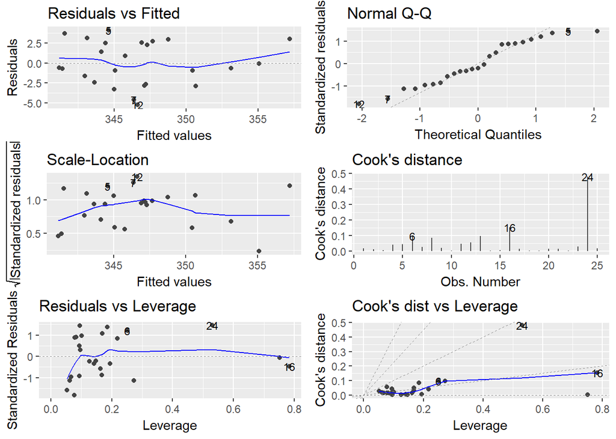

```r
autoplot(forwardBIC, which = 1:6, label.size = 3)
```

```r
summary(gvlma(forwardBIC))
```

```
##
## Call:
## lm(formula = reponse ~ descripteur30 + descripteur8 + descripteur39 +
##     descripteur8:descripteur39, data = dfAvecObs[c("reponse",
##     as.character(VifEffetsPrincipaux@results$Variables))])
##
## Residuals:
##     Min      1Q  Median      3Q     Max
## -5.2252 -2.3937 -0.5834  2.5760  4.1208
##
## Coefficients:
##                              Estimate Std. Error t value Pr(>|t|)
## (Intercept)                348.540867   2.683107 129.902  < 2e-16 ***
## descripteur30               -4.950314   1.023709  -4.836  0.00010 ***
## descripteur8                 4.315046   1.164961   3.704  0.00140 **
## descripteur39                0.006967   0.001893   3.681  0.00148 **
## descripteur8:descripteur39  -0.004747   0.001816  -2.614  0.01663 *
## ---
## Signif. codes:  0 '***' 0.001 '**' 0.01 '*' 0.05 '.' 0.1 ' ' 1
##
## Residual standard error: 3.004 on 20 degrees of freedom
## Multiple R-squared:   0.69,  Adjusted R-squared:  0.628
## F-statistic: 11.13 on 4 and 20 DF,  p-value: 6.468e-05
##
##
## ASSESSMENT OF THE LINEAR MODEL ASSUMPTIONS
## USING THE GLOBAL TEST ON 4 DEGREES-OF-FREEDOM:
## Level of Significance =  0.05
##
## Call:
##  gvlma(x = forwardBIC)
##
##                     Value p-value                Decision
## Global Stat        3.6995  0.4482 Assumptions acceptable.
## Skewness           0.1360  0.7123 Assumptions acceptable.
## Kurtosis           1.3300  0.2488 Assumptions acceptable.
## Link Function      1.6658  0.1968 Assumptions acceptable.
## Heteroscedasticity 0.5678  0.4511 Assumptions acceptable.
```

```r
car::outlierTest(forwardBIC)
```

```
##
## No Studentized residuals with Bonferonni p < 0.05
## Largest |rstudent|:
##     rstudent unadjusted p-value Bonferonni p
## 12 -1.930755           0.068574           NA
```

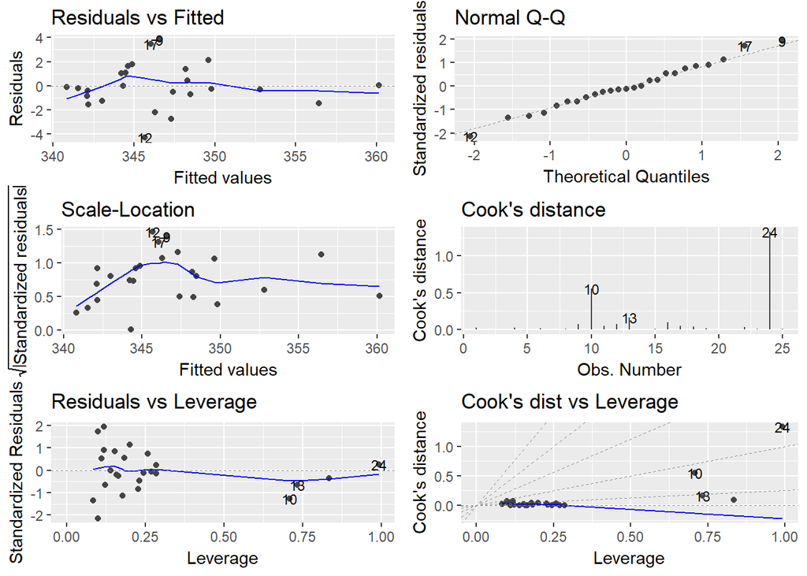

```r
autoplot(bidirectionalAIC, which = 1:6, label.size = 3)
```

```r
summary(gvlma(bidirectionalAIC))
```

```
##
## Call:
## lm(formula = reponse ~ descripteur30 + descripteur8 + descripteur39 +
##     descripteur31 + descripteur30:descripteur39 + descripteur30:descripteur31,
##     data = dfAvecObs[c("reponse", as.character(VifEffetsPrincipaux@results$Variables))])
##
## Residuals:
##     Min      1Q  Median      3Q     Max
## -4.2751 -0.8758 -0.2047  1.0612  3.8226
##
## Coefficients:
##                               Estimate Std. Error t value Pr(>|t|)
## (Intercept)                 358.327910   2.334952 153.463  < 2e-16 ***
## descripteur30               -21.740375   2.791524  -7.788 3.58e-07 ***
## descripteur8                  1.190662   0.359939   3.308  0.00391 **
## descripteur39                -0.005232   0.003566  -1.467  0.15954
## descripteur31                14.293998   5.834790   2.450  0.02475 *
## descripteur30:descripteur39   0.006222   0.001988   3.129  0.00579 **
## descripteur30:descripteur31   9.021816   2.443825   3.692  0.00167 **
## ---
## Signif. codes:  0 '***' 0.001 '**' 0.01 '*' 0.05 '.' 0.1 ' ' 1
##
## Residual standard error: 2.102 on 18 degrees of freedom
## Multiple R-squared:  0.8633, Adjusted R-squared:  0.8178
## F-statistic: 18.95 on 6 and 18 DF,  p-value: 7.033e-07
##
##
## ASSESSMENT OF THE LINEAR MODEL ASSUMPTIONS
## USING THE GLOBAL TEST ON 4 DEGREES-OF-FREEDOM:
## Level of Significance =  0.05
##
## Call:
##  gvlma(x = bidirectionalAIC)
##
##                       Value p-value                Decision
## Global Stat        3.011554  0.5559 Assumptions acceptable.
## Skewness           0.001963  0.9647 Assumptions acceptable.
## Kurtosis           0.066356  0.7967 Assumptions acceptable.
## Link Function      2.670979  0.1022 Assumptions acceptable.
## Heteroscedasticity 0.272256  0.6018 Assumptions acceptable.
```

```r
car::outlierTest(bidirectionalAIC)
```

```
##
## No Studentized residuals with Bonferonni p < 0.05
## Largest |rstudent|:
##     rstudent unadjusted p-value Bonferonni p
## 12 -2.411922           0.027456       0.6864
```

```r
attr(bidirectionalAIC$terms, "term.labels")
```

```
## [1] "descripteur30"               "descripteur8"
## [3] "descripteur39"               "descripteur31"
## [5] "descripteur30:descripteur39" "descripteur30:descripteur31"
```

## IV. Least absolute deviation regression

Matrice pour stocker les PRESS

On parcourt tous les 3-uplets des variables explicatives et construit un modèle de LAD. Puis, en comparant la PRESS de tous ces modèles trouvés, on en prend celui qui a la plus petite PRESS.

Cherchons la plus petite PRESS

```r
minimum2 <- min(RSS2)
minimum2
```

```
## [1] 582.2053
```

Quel modèle c’est ?

```
##      dim1 dim2 dim3
## [1,]    8   12   18
```

On étudie ce modèle

```
## Call:
## lad(formula = reponse ~ .^2, data = dfAvecObs[c("reponse", as.character(VifEffetsPrincipaux@results$Variables)[c(8,
##     12, 18)])])
##
## Residuals:
##    Min     1Q Median     3Q    Max
## -6.513 -1.855  0.000  1.192  7.699
##
## Coefficients:
##                              Estimate  Std.Error Z value   p-value
## (Intercept)                  352.9372   67.4671    5.2312    0.0000
## descripteur30                -40.6312   27.5220   -1.4763    0.1399
## descripteur45                  0.7777  104.4313    0.0074    0.9941
## descripteur68                374.9714  182.2911    2.0570    0.0397
## descripteur30:descripteur45   57.6348   41.1318    1.4012    0.1611
## descripteur30:descripteur68   -5.1703   23.8913   -0.2164    0.8287
## descripteur45:descripteur68 -567.8357  296.0946   -1.9178    0.0551
##
## Degrees of freedom: 25 total; 18 residual
## Scale estimate: 3.030972
## Log-likelihood: -61.38642 on 8 degrees of freedom
```

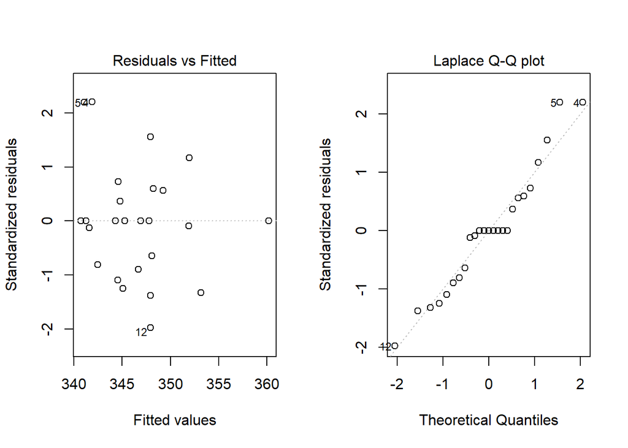

```
## Call:
## lad(formula = reponse ~ .^2 - descripteur30:descripteur68, data = dfAvecObs[c("reponse",
##     as.character(VifEffetsPrincipaux@results$Variables)[c(8,
##         12, 18)])])
##
## Residuals:
##    Min     1Q Median     3Q    Max
## -6.206 -1.146  0.000  1.282  8.168
##
## Coefficients:
##                              Estimate  Std.Error Z value   p-value
## (Intercept)                  343.5487   67.8226    5.0654    0.0000
## descripteur30                -35.1871   26.5570   -1.3250    0.1852
## descripteur45                 18.2061  103.2472    0.1763    0.8600
## descripteur68                333.7068  179.7528    1.8565    0.0634
## descripteur30:descripteur45   48.1797   41.2758    1.1673    0.2431
## descripteur45:descripteur68 -526.6669  270.3606   -1.9480    0.0514
##
## Degrees of freedom: 25 total; 19 residual
## Scale estimate: 3.047501
## Log-likelihood: -61.52238 on 7 degrees of freedom
```

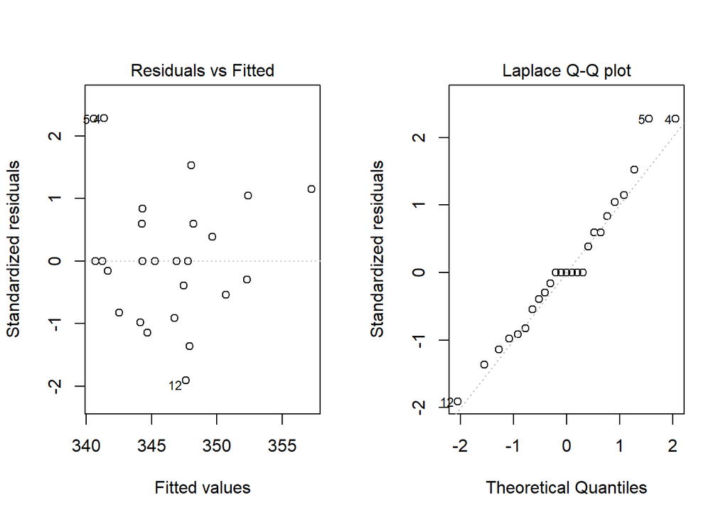

```
## Call:
## lad(formula = reponse ~ .^2 - descripteur30:descripteur68, data = dfAvecObs[-c(5,
##     4, 12), c("reponse", as.character(VifEffetsPrincipaux@results$Variables)[c(8,
##     12, 18)])])
##
## Residuals:
##     Min      1Q  Median      3Q     Max
## -4.7857 -1.2068  0.0000  0.2164  3.6218
##
## Coefficients:
##                              Estimate  Std.Error Z value   p-value
## (Intercept)                  338.3764   42.2731    8.0045    0.0000
## descripteur30                -50.5823   16.6832   -3.0319    0.0024
## descripteur45                 26.6633   64.3367    0.4144    0.6786
## descripteur68                562.8814  113.5691    4.9563    0.0000
## descripteur30:descripteur45   72.1070   25.9546    2.7782    0.0055
## descripteur45:descripteur68 -881.4859  171.8861   -5.1283    0.0000
##
## Degrees of freedom: 22 total; 16 residual
## Scale estimate: 1.896715
## Log-likelihood: -43.70733 on 7 degrees of freedom
```

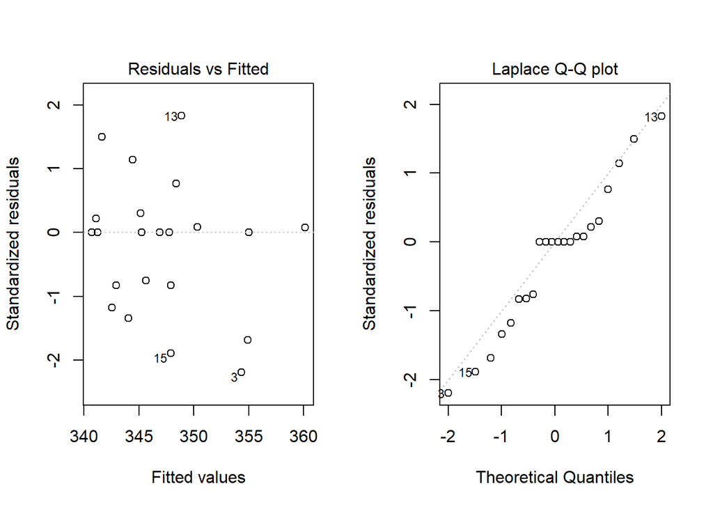

——– FIN ———-